# Live tutorial

## Get started with lubridate

Lubridate it is a very useful package when you have to work with dates. Let’s see how to download and install (spoiler: it is as any other R packages). Digit on the console install.packages(“lubridate”) and then… load it!

```r
library(tidyverse)
library(lubridate)
```

Once you have done it we can start to work with it. Let’s start with the easy, but very useful. functions. How many times do you need to convert number or string in a date? (I know, none. But that is what we are doing okay, so keep attention).

```r
ymd('1948-11-13')
```

```
## [1] "1948-11-13"
```

```r
ydm('19982111')
```

```
## [1] "1998-11-21"
```

```r
ydm(19982111)
```

```
## [1] "1998-11-21"
```

Wow! If you were focused you notice that the functions called are different.Let me explain: y = years, d = day, m = month and you can use the order that you need! Cool, isn’t it? It works in very different situations, when it fails?

```r
ymd('1948-13-13')
```

```
## [1] NA
```

```r
ydm(19584105)
```

```
## [1] NA
```

```r
ydm('199821111')
```

```
## [1] NA
```

One interesting features of the library is to manage with time zone.

```r
french_revolution <- mdy_hm('jul 14st, 1789 12:34', tz = 'cet')
french_revolution
```

```
## [1] "1789-07-14 12:34:00 CET"
```

```r
with_tz(french_revolution, tz = 'America/Bogota')
```

```
## [1] "1789-07-14 06:37:44 LMT"
```

Everyone love works with tidy data, but be realistic how many times this happen? Lubridate helps you also with that.

```r
x <- c("09-07-01", "05-01-02", "09-01-13", "09-11-2003")

parse_date_time(x, "ymd")
```

```
## [1] "2009-07-01 UTC" "2005-01-02 UTC" "2009-01-13 UTC" NA
```

```r
parse_date_time(x, c("ymd", "dmy"))
```

```
## [1] "2009-07-01 UTC" "2005-01-02 UTC" "2009-01-13 UTC" "2003-11-09 UTC"
```

I wont know show the more useful function of the library: make_datetime. Given the input of year, month, day, hours, … it return the date. Let’s apply it to a small dataset to see how it works.

```r
d = data.frame(day = c(2,5,23,31), month = c(3,6,12,4), year = c(1996,1998,2003,1345))
d
```

```
##   day month year
## 1   2     3 1996
## 2   5     6 1998
## 3  23    12 2003
## 4  31     4 1345
```

```r
d %>%
  select(year, month, day) %>%
  mutate(date = make_datetime(year, month, day))
```

```
##   year month day       date
## 1 1996     3   2 1996-03-02
## 2 1998     6   5 1998-06-05
## 3 2003    12  23 2003-12-23
## 4 1345     4  31 1345-05-01
```

Now that we know the bases from this and the presentation try to apply them. We are facing a well known problem. Know the age of death of the Cech Repubblic deputies.

```r
library(legislatoR)

cze_core <- get_core(legislature = "cze")

cze_core %>%
  filter(!is.na(death)) %>%
  mutate(life_duration = interval((birth),(death))) %>%
  mutate(life_duration = life_duration %/% years(1)) %>%
  pull(life_duration)
```

```
##  [1] 68 56 60 76 45 73 77 66 67 72 68 70 67 48 76 66 83 67 70 69 62 58 74 72 75
## [26] 57 75 43 63 45 62 67 57 88 59 66 60 73 62 65 51 64 60 67 72 62 38
```

Wow very quick, I passed hours on this exercise a couple of weeks ago… Almost finished, let’s have some fun. Who wants to plot the day of the week in wich the politicians born?

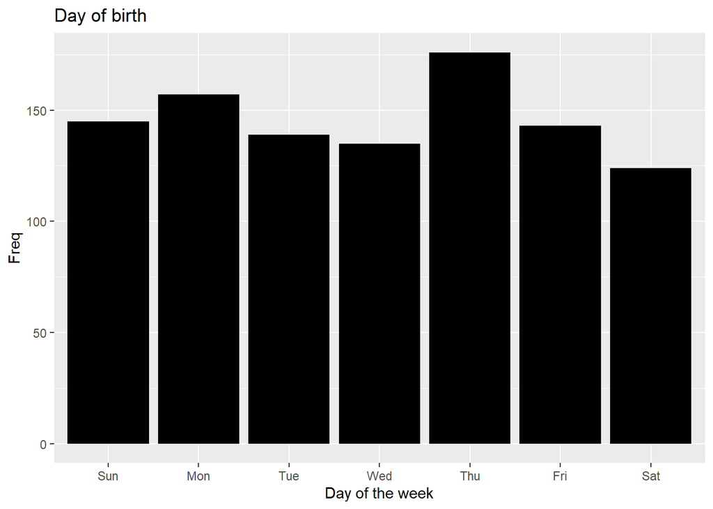

```r
cze_core %>%
  mutate(day_birth = wday(birth, label = T)) %>%
  filter(!is.na(day_birth)) %>%
  ggplot(aes(x = day_birth)) +
  geom_bar(fill="black") +
  labs(x = 'Day of the week' , y = 'Freq', title = "Day of birth")
```